# Out-of-Pocket Payment for Ambulatory Blood Pressure Monitoring Among Commercially Insured in the United States | American Journal of Hypertension | Oxford Academic

[figure not shown]

[figure not shown]

[figure not shown]

Volume 33

Issue 11

November 2020

### Article Contents

Journal Article

# Out-of-Pocket Payment for Ambulatory Blood Pressure Monitoring Among Commercially Insured in the United States

Raj Desai, Eric A Dietrich, Haesuk Park, Steven M Smith

*American Journal of Hypertension*, Volume 33, Issue 11, November 2020, Pages 999–1002, https://doi.org/10.1093/ajh/hpaa120

Published:

15 September 2020

Article history

## Abstract

Background

Clinical guidelines increasingly recommended ambulatory blood pressure monitoring (ABPM) for hypertension diagnosis and management. Yet, ABPM is used infrequently in the United States, possibly because of low insurance coverage and high patient costs. We sought to analyze out-of-pocket payments (OPPs) for ABPM among privately insured patients.

Methods

We conducted a retrospective analysis using IBM® MarketScan® commercial claims of beneficiaries aged ≥18 years receiving ABPM from January 2012 to December 2018. The date of first ABPM claim (Healthcare Common Procedure Coding System codes 93784, 93786, 93788, or 93790) was considered the index date. Patients with 12 months of continuous enrollment preindex and 30-day postindex were included. Per beneficiary OPP was calculated by aggregating all ABPM-related OPPs within the 30-day postindex window (ABPM episode).

Results

Of 22,317 beneficiaries receiving ABPM, 62% had $0 OPP and 38% had OPP >$0. Among the latter, median OPP per beneficiary for an ABPM episode was $23 (interquartile range [IQR], $14, $32), driven primarily by full ABPM claims (median, $22; IQR, $14, $24). Among individual components, scan analysis and report claims (median, $25; IQR, $13, $49) had the greatest OPP. The median OPP per ABPM episode did not change substantively from 2012 through 2018.

Conclusions

Among commercially insured in the United States, nearly 4-in-10 have an OPP for ABPM. Though most OPPs are relatively modest, some patients incur substantial OPP. Our findings highlight the need for policymakers to ensure adequate ABPM coverage in the commercial insurance marketplace.

ABPM, blood pressure, hypertension, monitoring, out-of-pocket payment

Issue Section:

[Brief Communication](https://academic.oup.com/ajh/search-results?f_TocHeadingTitle=Brief+Communication)

Hypertension guidelines increasingly recommend out-of-office blood pressure (BP) measurement to confirm hypertension diagnoses and identify white coat hypertension and masked hypertension.<sup>1–3</sup> Ambulatory BP monitoring (ABPM) provides more reliable and stable BP measurement than office BP. However, ABPM is underutilized in the United States,<sup>4</sup> where the costs of the device and its maintenance, including training of administrative and medical staff to fit the device and interpret BP readings, remain relatively high.<sup>5</sup> Medicare pays a median rate of $52, varying modestly by geographic region, per ABPM session.<sup>6</sup> Among commercial insurers in the United States, the median reimbursement to providers for each ABPM episode is $89.<sup>7</sup> However, to date, out-of-pocket payment (OPP) for ABPM in the commercial insurance marketplace has not been studied. Given that high OPP may be a significant barrier to patient acceptance of ABPM, we sought to characterize ABPM OPPs in a nationally representative US cohort of patients with commercial insurance.

## METHODS

We conducted a retrospective analysis of IBM® MarketScan® commercial claims database including adult beneficiaries who received ABPM between 2012 and 2018, inclusive. This database includes records of patient enrollment, inpatient and outpatient medical claims, expenditures, and outpatient prescription drug claims for over 150 million beneficiaries covered under a variety of commercial health benefit plans. Furthermore, the database is generally considered to be representative of the US population receiving employer-sponsored medical insurance (approximately 49% of the US population).<sup>8</sup> This study was approved by the Institutional Review Board at the University of Florida.

We identified beneficiaries aged ≥18 years with an ABPM claim (identified by current procedural terminology [CPT] codes 93784, 93786, 93788, or 93790) between January 2012 and December 2018. The date of first ABPM claim was considered the index date. Patients without continuous medical and pharmacy benefits during the 12 months before, and 30 days after the index date were excluded. Because ABPM takes place over multiple days and different components can be billed across multiple days, we grouped all ABPM-related claims within the 30 days following the initial claim as an “ABPM episode.” The primary outcome was the OPP associated with the ABPM episode, calculated by summing copay and coinsurance amounts within the ABPM episode. To examine the contribution of deductibles to OPP, i.e., for patients not reaching their deductible before ABPM, we also conducted sensitivity analyses aggregating the amounts of the copay, coinsurance, and deductible to calculate the OPP. In both scenarios, we focused our analyses of OPP on patients who paid some OPP (i.e., >$0). All OPP amounts were adjusted to 2018 US dollars using a 3% inflation rate. Additionally, we evaluated trends over time in OPP via the following measures: (i) the proportion of patients with any OPP >$0 among all of those with an ABPM episode; (ii) the median OPP per year (adjusted to 2018 US dollars), among those with OPP >$0; and, (iii) the proportion of total payment per ABPM episode contributed by the patient (i.e., OPP divided by OPP + provider reimbursement). All probability values were considered significant at *P* < 0.05. Statistical analyses were performed using SAS 9.4 (SAS Institute, Cary, NC).

## RESULTS

Of 22,317 adult beneficiaries with an ABPM claim, 13,880 (62%) of patients had no OPP and the remaining 8,437 (38%) had an OPP >$0. Baseline characteristics of both groups are summarized in Supplementary Table S1 online. In general, patients with $0 OPP were similar to those with >$0 OPP, including on age, sex, history of hypertension diagnosis, and other comorbidities. Notable differences included geographic region and benefit plan type. Compared with those with no OPP, patients with an OPP >$0 were more often located in the Northeast (46% vs. 34%, *P* < 0.0001) and less often located in the South (24% vs. 33%, *P* < 0.0001). And, those with >$0 OPP were more likely to be insured in a Preferred Provider Organization (PPO) (69% vs. 53%, *P* < 0.0001) and less likely to be insured under other benefit plan type. Supplementary Table S2 online summarizes the baseline characteristics of adult beneficiaries having OPP >$0 stratified by OPP above the median (high OPP) vs. below the median (low OPP). Patients having high OPP, compared with those with low OPP, were more often insured in Health Maintenance Organizations (HMOs) (8.5% vs. 6.9%, *P* = 0.025), located in the Northeast (49.8% vs. 42.9%, *P* < 0.0001) and had a modestly higher prevalence of chronic kidney disease (5.4% vs. 4.4%, *P* = 0.025).

The distribution of OPP, among those with an OPP >$0, is summarized in Figure 1 (Panel a). The median OPP per ABPM episode was $23 (interquartile range [IQR], $14, $32), and OPPs of ≥$50 and ≥$100 were observed for approximately 13% and 4%, respectively, of beneficiaries. These data largely mirrored those for full procedures, which comprised 63% of all ABPM claims and incurred a median OPP of $22 (IQR, $14, $24). Stratifying by individual components of ABPM, the highest median OPP was for scan analysis and report claims at $25 (IQR, $13, $49) followed by procedure recording at $22 (IQR, $13, $44) and physician review and report at $6 (IQR, $4, $17).

Figure 1.

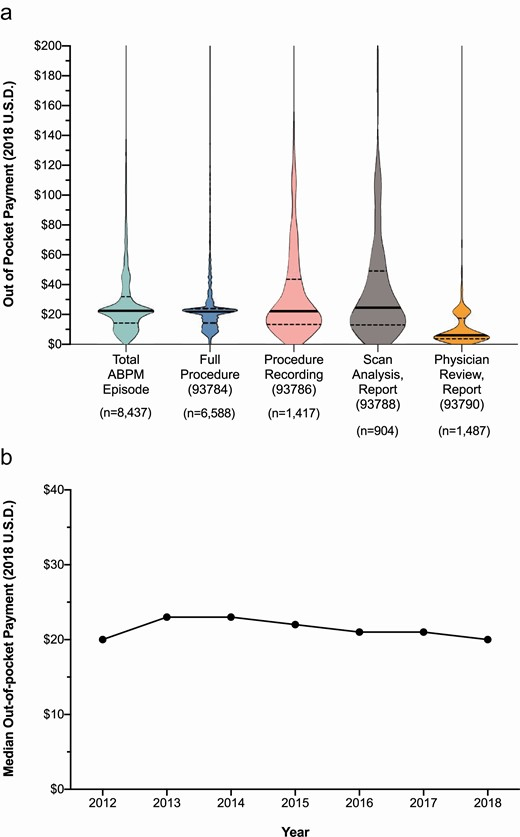

Out-of-pocket payment for overall ABPM episode, stratified by procedure code (Panel **a**) and change in median out-of-pocket payment per ABPM episode from 2012 through 2018 (Panel **b**). For both panels, data include only patients who incurred an out-of-pocket payment (*n* = 8,437). The *y*-axis in Panel a is truncated at $200. Codes specified for each procedure represent the Current Procedural Technology code. Abbreviation: ABPM, ambulatory blood pressure monitoring. In Panel a, the solid line represents the median, the dashed lines represent the 25th (below the solid line) and 75th percentile (above the solid line). Summary data underlying these figures are included in the online data supplement.

HMOs were associated with slightly higher median OPPs ($23, IQR, $16, $34) compared with PPOs ($22, IQR, $15, $29), Consumer Directed Health Plans (CDHPs) ($21, IQR, $12, $46), and Point of Service (POS) plans ($22, IQR, $11, $34), as summarized in Supplementary Figure S1 online. When stratified by plan type and procedure code, CDHPs were associated with higher OPPs for procedure recording and scan analysis than full ABPM, as well as higher OPPs for these same components compared with other plan types (Supplementary Figure S2 online). Patients in PPOs had only modestly higher OPPs for the individual components compared with full procedure, whereas for patients in HMO plans, the individual components of ABPM incurred lower OPPs than the full procedure.

As shown in Figure 1, Panel b, the median OPP per ABPM episode increased modestly during the early years of the study (i.e., 2012–2013), but thereafter gradually returned to 2012 levels by 2018 (median, $20, in both years). The proportion of total payment contributed by the patient for an ABPM episode increased slightly from 19% in 2012 to 21% in 2018 (Supplementary Figure S4 online).

In sensitivity analysis adding deductibles to OPP calculations, the median OPP per beneficiary ABPM episode increased to $29 (IQR, $20, $82). Median OPP for full procedure ($24), procedure recording ($46), scan analysis and report claims ($43), and physician review and report ($17) in the 30-day ABPM window also increased.

## Discussion

ABPM has been recommended consistently for decades in a substantial portion of patients with hypertension, and the most recent US hypertension guidelines have further expanded recommendations for its use.<sup>1–3</sup> Nevertheless, our prior work suggests that such recommendations have not translated to clinical care in the United States. For example, we previously showed that ABPM claim submissions decreased from 2008 to 2017 and fewer than 0.5% of commercially insured patients with hypertension have had ABPM claims billed to their commercial insurance.<sup>4,7</sup> We hypothesized that one possible explanation for these findings could be low patient acceptance, either because ABPM is cumbersome or because of OPP burden. Our present findings suggest the latter may not be the primary barrier for most individuals with coverage, particularly when excluding deductibles from OPP calculation. However, we were able to study only individuals who ultimately had ABPM performed and it is possible that faced with higher potential OPPs, some patients were dissuaded from electing to complete ABPM.

Prior research evaluating quality-adjusted life-years and lifetime costs of clinic, home, and ambulatory BP measurement for hypertension diagnosis in primary care suggests that use of ABPM leads to greater lifetime savings ranging from $77 (for older individuals) to $5,013 (for younger individuals) compared with clinic BP measurements, in part because it can detect white coat hypertension and masked hypertension.<sup>9</sup> Such detection can have implications on subsequent treatment, namely by encouraging long-term therapy in those at higher risk (sustained and masked hypertension) and potentially avoiding long-term therapy in those with lower risk. Unfortunately, we could not determine patient perceptions of the OPP burden, nor patients views of the trade-off between OPP and long-term savings of ABPM.

Somewhat surprisingly, the individual components of ABPM, other than physician review and report, were associated with similar or higher OPPs than full ABPM (CPT 93784) in the overall cohort (Figure 1, Panel a) across each plan type, other than HMOs (Supplementary Figure S2 online). We previously noted similar findings for provider reimbursement, where scan analysis and report and procedure recording were associated with considerably greater reimbursement than the full procedure code.<sup>7</sup> However, some limitations of the data make interpretation of these results challenging. First, the data do not contain indicators for individual health plans, making it impossible to compare CPT codes within a particular health plan. Second, the vast majority of patients do not undergo repeated ABPM sessions, at least in the timeframe of the MarketScan data, making it challenging to compare CPT codes within particular individuals. Thus, it remains unclear whether these findings truly represent greater reimbursement and greater OPPs when the component codes are used vs. the full procedure code. It is entirely plausible that any observed differences in OPPs comparing codes stem from the much smaller number of claims, and greater variability in OPP, with individual component codes.

Strengths of this study including a large, diverse population of commercially insured individuals with detailed information regarding adjudicated payments. Nevertheless, this study has limitations. First, our results likely are not generalizable to patients enrolled in health plans not covering ABPM services, and it remains unclear to what extent commercial plans cover ABPM in the United States. Second, the data source specifies only plan type, not individual plan identifiers, thus precluding analyses of OPP variation across individual health plans within plan type (e.g., comparing individual PPOs). Relatedly, given that we observed some variation in OPP across plan types, our overall results should be considered in the context of the distribution of plan types among patients in our cohort. Finally, as noted previously, we were unable to study OPPs for ABPM that were ultimately refused by patients or payers, and it remains unclear to what extent higher OPPs may have been a barrier for patients in whom ABPM would be indicated but was ultimately not performed.

In conclusion, our data show relatively modest OPP for most patients receiving ABPM, and suggest that OPP may not be a major cause of infrequent ABPM use in the United States. Nevertheless, our data reinforce the need for patients, physicians, and policymakers to advocate for adequate ABPM coverage in the commercial insurance marketplace and minimize cost sharing for the patients, particularly in light of the fact that ABPM is not used routinely to monitor BP. Future research should investigate reasons for variability in OPP for ABPM, the extent to which high OPP may prevent ABPM use and downstream consequences of ABPM avoidance.

## Funding

Dr Smith is supported by the National Heart, Lung and Blood Institute (K01 HL138172).

## DISCLOSURE

The authors declared no conflict of interest.

## References

1.

Whelton

PK

,

Carey

RM

,

Aronow

WS

,

Casey

DE

Jr,

Collins

KJ

,

Dennison Himmelfarb

C

,

DePalma

SM

,

Gidding

S

,

Jamerson

KA

,

Jones

DW

,

MacLaughlin

EJ

,

Muntner

P

,

Ovbiagele

B

,

Smith

SC

Jr,

Spencer

CC

,

Stafford

RS

,

Taler

SJ

,

Thomas

RJ

,

Williams

KA

Sr,

Williamson

JD

,

Wright

JT

Jr.

2017 ACC/AHA/AAPA/ABC/ACPM/AGS/APhA/ASH/ASPC/NMA/PCNA guideline for the prevention, detection, evaluation, and management of high blood pressure in adults: a report of the American College of Cardiology/American Heart Association Task Force on Clinical Practice Guidelines

.

Hypertension

2018

;

71

:

e13

–

e115

.

Google Scholar

[PubMed](http://www.ncbi.nlm.nih.gov/pubmed/29133356)

Find in my library

WorldCat

2.

Williams

B

,

Mancia

G

,

Spiering

W

,

Agabiti Rosei

E

,

Azizi

M

,

Burnier

M

,

Clement

DL

,

Coca

A

,

de Simone

G

,

Dominiczak

A

,

Kahan

T

,

Mahfoud

F

,

Redon

J

,

Ruilope

L

,

Zanchetti

A

,

Kerins

M

,

Kjeldsen

SE

,

Kreutz

R

,

Laurent

S

,

Lip

GYH

,

McManus

R

,

Narkiewicz

K

,

Ruschitzka

F

,

Schmieder

RE

,

Shlyakhto

E

,

Tsioufis

C

,

Aboyans

V

,

Desormais

I

;

ESC Scientific Document Group

.

2018 ESC/ESH Guidelines for the management of arterial hypertension

.

Eur Heart J

2018

;

39

:

3021

–

3104

.

Google Scholar

[Crossref](http://dx.doi.org/10.1093/eurheartj/ehy339)

[Find in my library](https://ufl-flvc.primo.exlibrisgroup.com/openurl/01FALSC_UFL/01FALSC_UFL:UFL?rft_id=info%3Adoi%2F10.1093%2Feurheartj%2Fehy339)

[PubMed](http://www.ncbi.nlm.nih.gov/pubmed/30165516)

[WorldCat](https://www.worldcat.org/search?q=ti:2018%20ESC%2FESH%20Guidelines%20for%20the%20management%20of%20arterial%20hypertension&qt=advanced&dblist=638)

3.

Shimbo

D

,

Abdalla

M

,

Falzon

L

,

Townsend

RR

,

Muntner

P

.

Role of ambulatory and home blood pressure monitoring in clinical practice: a narrative review

.

Ann Intern Med

2015

;

163

:

691

–

700

.

Google Scholar

[Crossref](http://dx.doi.org/10.7326/M15-1270)

[Find in my library](https://ufl-flvc.primo.exlibrisgroup.com/openurl/01FALSC_UFL/01FALSC_UFL:UFL?rft_id=info%3Adoi%2F10.7326%2FM15-1270)

[PubMed](http://www.ncbi.nlm.nih.gov/pubmed/26457954)

[WorldCat](https://www.worldcat.org/search?q=ti:Role%20of%20ambulatory%20and%20home%20blood%20pressure%20monitoring%20in%20clinical%20practice%3A%20a%20narrative%20review&qt=advanced&dblist=638)

4.

Desai

R

,

Park

H

,

Dietrich

EA

,

Smith

SM

.

Trends in ambulatory blood pressure monitoring use for confirmation or monitoring of hypertension and resistant hypertension among the commercially insured in the U.S., 2008–2017

.

Int J Cardiol Hypertens

2020

;

6

:

100033

.

Google Scholar

[Crossref](http://dx.doi.org/10.1016/j.ijchy.2020.100033)

[Find in my library](https://ufl-flvc.primo.exlibrisgroup.com/openurl/01FALSC_UFL/01FALSC_UFL:UFL?rft_id=info%3Adoi%2F10.1016%2Fj.ijchy.2020.100033)

[PubMed](http://www.ncbi.nlm.nih.gov/pubmed/33447762)

WorldCat

5.

Kronish

IM

,

Kent

S

,

Moise

N

,

Shimbo

D

,

Safford

MM

,

Kynerd

RE

,

O’Beirne

R

,

Sullivan

A

,

Muntner

P

.

Barriers to conducting ambulatory and home blood pressure monitoring during hypertension screening in the United States

.

J Am Soc Hypertens

2017

;

11

:

573

–

580

.

Google Scholar

[Crossref](http://dx.doi.org/10.1016/j.jash.2017.06.012)

[Find in my library](https://ufl-flvc.primo.exlibrisgroup.com/openurl/01FALSC_UFL/01FALSC_UFL:UFL?rft_id=info%3Adoi%2F10.1016%2Fj.jash.2017.06.012)

[PubMed](http://www.ncbi.nlm.nih.gov/pubmed/28734798)

WorldCat

6.

Kent

ST

,

Shimbo

D

,

Huang

L

,

Diaz

KM

,

Viera

AJ

,

Kilgore

M

,

Oparil

S

,

Muntner

P

.

Rates, amounts, and determinants of ambulatory blood pressure monitoring claim reimbursements among Medicare beneficiaries

.

J Am Soc Hypertens

2014

;

8

:

898

–

908

.

Google Scholar

[Crossref](http://dx.doi.org/10.1016/j.jash.2014.09.020)

[Find in my library](https://ufl-flvc.primo.exlibrisgroup.com/openurl/01FALSC_UFL/01FALSC_UFL:UFL?rft_id=info%3Adoi%2F10.1016%2Fj.jash.2014.09.020)

[PubMed](http://www.ncbi.nlm.nih.gov/pubmed/25492833)

WorldCat

7.

Dietrich

E

,

Desai

R

,

Garg

M

,

Park

H

,

Smith

SM

.

Reimbursement of ambulatory blood pressure monitoring in the US commercial insurance marketplace

.

J Clin Hypertens (Greenwich)

2020

;

22

:

6

–

15

.

Google Scholar

[Crossref](http://dx.doi.org/10.1111/jch.v22.1)

[Find in my library](https://ufl-flvc.primo.exlibrisgroup.com/openurl/01FALSC_UFL/01FALSC_UFL:UFL?rft_id=info%3Adoi%2F10.1111%2Fjch.v22.1)

[PubMed](http://www.ncbi.nlm.nih.gov/pubmed/31873973)

[WorldCat](https://www.worldcat.org/search?q=ti:Reimbursement%20of%20ambulatory%20blood%20pressure%20monitoring%20in%20the%20US%20commercial%20insurance%20marketplace&qt=advanced&dblist=638)

8.

IBM Corporation

.

MarketScan Research Databases for Health Services Researchers

. https://www.ibm.com/downloads/cas/6KNYVVQ2. 2019. Accessed

25 May 2020

.

9.

Beyhaghi

H

,

Viera

AJ

.

Comparative cost-effectiveness of clinic, home, or ambulatory blood pressure measurement for hypertension diagnosis in US adults

.

Hypertension

2019

;

73

:

121

–

131

.

Google Scholar

[Crossref](http://dx.doi.org/10.1161/HYPERTENSIONAHA.118.11715)

[Find in my library](https://ufl-flvc.primo.exlibrisgroup.com/openurl/01FALSC_UFL/01FALSC_UFL:UFL?rft_id=info%3Adoi%2F10.1161%2FHYPERTENSIONAHA.118.11715)

[PubMed](http://www.ncbi.nlm.nih.gov/pubmed/30571548)

WorldCat

10.

Head

GA

.

Ambulatory blood pressure monitoring is ready to replace clinic blood pressure in the diagnosis of hypertension: pro side of the argument

.

Hypertension

2014

;

64

:

1175

–

1181; discussion 1181

.

Google Scholar

[Crossref](http://dx.doi.org/10.1161/HYPERTENSIONAHA.114.03882)

[Find in my library](https://ufl-flvc.primo.exlibrisgroup.com/openurl/01FALSC_UFL/01FALSC_UFL:UFL?rft_id=info%3Adoi%2F10.1161%2FHYPERTENSIONAHA.114.03882)

[PubMed](http://www.ncbi.nlm.nih.gov/pubmed/25331849)

WorldCat

11.

Khera

R

,

Valero-Elizondo

J

,

Okunrintemi

V

,

Saxena

A

,

Das

SR

,

de Lemos

JA

,

Krumholz

HM

,

Nasir

K

.

Association of out-of-pocket annual health expenditures with financial hardship in low-income adults with atherosclerotic cardiovascular disease in the United States

.

JAMA Cardiol

2018

;

3

:

729

–

738

.

Google Scholar

[Crossref](http://dx.doi.org/10.1001/jamacardio.2018.1813)

[Find in my library](https://ufl-flvc.primo.exlibrisgroup.com/openurl/01FALSC_UFL/01FALSC_UFL:UFL?rft_id=info%3Adoi%2F10.1001%2Fjamacardio.2018.1813)

[PubMed](http://www.ncbi.nlm.nih.gov/pubmed/29971325)

WorldCat

© The Author(s) 2020. Published by Oxford University Press on behalf of American Journal of Hypertension, Ltd. All rights reserved. For permissions, please e-mail: journals.permissions@oup.com

This article is published and distributed under the terms of the Oxford University Press, Standard Journals Publication Model (https://academic.oup.com/pages/standard-publication-reuse-rights)

## Supplementary data

hpaa120_suppl_Supplementary_Material - docx file

hpaa120_suppl_Supplementary_Data - xlsx file

[figure not shown]

[figure not shown]